# Compare Treatments KRN 2019

Emilio A. Laca

6/17/2021

# THIS SCRIPT ANALYZES THE DIFFERENCES BETWEEN UNITS THAT WERE DISKED OR NOT AND FLOODED OR NOT.

# AN HTML REPORT IS SUPPOSED TO BE PRODUCED.

## Data input and exploration

```r
# Use qdt_mass_g_m2 from WHAP_Main_Script_2019.Rmd

qdt_mass_g_m2_2019 <- read.csv("qdt_mass_g_m2_2019.txt") %>%
  dplyr::select(-X) %>%
  dplyr::filter(LIT == "KRN")

# There is data on act only for KRN and most of the flooding data is for KRN.
# Thus, only KRN data are used for these comparisons.

act <- read.csv("WHAP2019_PP_20201002_MUs_KRN_Actions_v2.csv",
                na.strings=c(""," ","NA")) %>%
  mutate(subunit_ID = paste(LIT, Unit_Name, Subunit_Name, sep = "_"),
         act = factor(Action_yn),
         Action = replace_na(Action, "none")) %>%
  dplyr::filter(LIT == "KRN") %>%
  dplyr::select(LIT,
                Unit_Name,
                Subunit_Name,
                subunit_ID,
                act,
                Action)

# effects of flooding in KRN

# y.flooded.n are number of years flooded out of the last n
# y20167, y20178, y20189 are flooding in the last 3 seasons up to 2019

water2 <- read.csv("Kern_Flooding_Schedule.csv") %>%
  mutate(LIT = "KRN",
         Subunit_Name = SubUnit) %>%
  dplyr::select(LIT,
         Subunit_Name,
         starts_with("y"))

qdt_mass_act_fld <- left_join(qdt_mass_g_m2_2019, act) %>%
  left_join(water2) %>%
  dplyr::select(LIT,
                Unit_Name,
                Subunit_Name,
                subunit_ID,
                act,
                Action,
                y.flooded.15,
                y.flooded.5,
                y20167,
                y20178,
                y20189,
                st_g_m2, # none of the subunits have watergrass
                st_mass_m2_var) %>%
  drop_na() %>%
  mutate(wt = 1 / sqrt(st_mass_m2_var),
         wt = length(st_g_m2) * wt / sum(wt))
str(qdt_mass_act_fld)
```

```
## 'data.frame':    36 obs. of  14 variables:
##  $ LIT           : chr  "KRN" "KRN" "KRN" "KRN" ...
##  $ Unit_Name     : chr  "14" "14" "14" "14" ...
##  $ Subunit_Name  : chr  "14A-1" "14A-2" "14B-1" "14B-2" ...
##  $ subunit_ID    : chr  "KRN_14_14A-1" "KRN_14_14A-2" "KRN_14_14B-1" "KRN_14_14B-2" ...
##  $ act           : Factor w/ 2 levels "N","Y": 1 1 1 1 1 1 1 1 1 1 ...
##  $ Action        : chr  "none" "none" "none" "none" ...
##  $ y.flooded.15  : int  12 12 10 11 9 9 10 9 10 9 ...
##  $ y.flooded.5   : int  4 4 3 3 2 2 3 2 3 2 ...
##  $ y20167        : chr  "Flooded" "Flooded" "Flooded" "Flooded" ...
##  $ y20178        : chr  "Flooded" "Flooded" "Flooded" "Flooded" ...
##  $ y20189        : chr  "Flooded" "Flooded" "Flooded" "Flooded" ...
##  $ st_g_m2       : num  4.19 4.08 96.83 41.39 84.92 ...
##  $ st_mass_m2_var: num  15.1 154.7 670.8 176.1 669.7 ...
##  $ wt            : num  0 0 0 0 0 0 0 0 0 NaN ...
```

The raw data plots seems to indicate that the history of flooding is not associated with swamp timothy productivity. Conversely, those units that were disced in the previous three years had higher yields of swamp timothy than the units that were not tilled.

```r
table(qdt_mass_act_fld$Action) %>%
  as.data.frame() %>%
  rename(Tillage = Var1) %>%
  kable(caption = "Number of units that receive each type of tillage treatment in Kern prior to the 2019 season.") %>%
  kableExtra::kable_styling(full_width = FALSE)
```

Number of units that receive each type of tillage treatment in Kern prior to the 2019 season.

| Tillage | Freq |
| --- | --- |
| disced 2016 | 1 |
| disced 2017 and 2018 | 3 |
| disced 2018 | 1 |
| none | 31 |

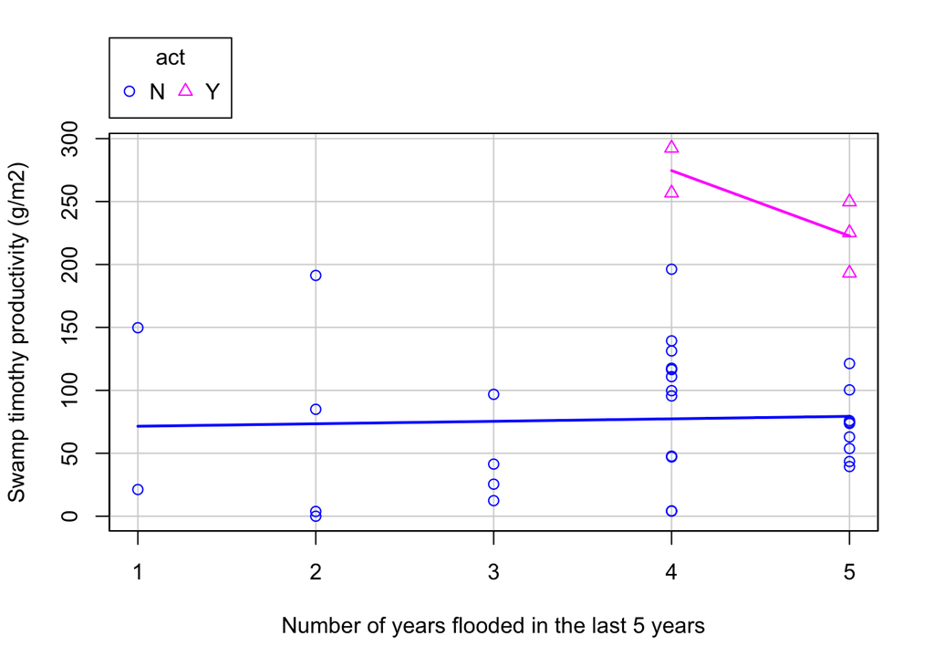

```r
scatterplot(st_g_m2 ~ y.flooded.5 | act,
            data = qdt_mass_act_fld,
            smooth = FALSE,
            ylab = "Swamp timothy productivity (g/m2)",
            xlab = "Number of years flooded in the last 5 years")
```

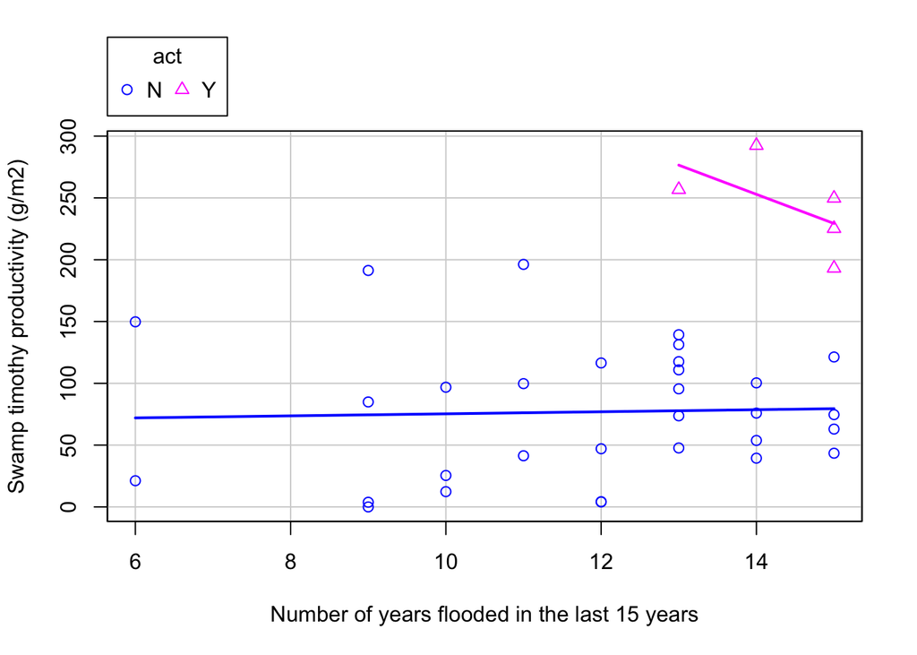

```r
scatterplot(st_g_m2 ~ y.flooded.15 | act,
            data = qdt_mass_act_fld,
            smooth = FALSE,
            ylab = "Swamp timothy productivity (g/m2)",
            xlab = "Number of years flooded in the last 15 years")
```

## Analyze **apparent** effects of “treatments”

These analyses should be interpreted with caution. Apparent effects of treatments cannot be attributed to treatments because there was no randomization in the selection of units to be flooded. Based on my understanding of management decisions, flooding is decided on the basis of the potential of units to express higher production. Therefore, I am suspicious that there may be a selection bias in the results.

```r
brm1 <- brm(st_g_m2 | weights(wt) ~ act * y.flooded.15,
            data = qdt_mass_act_fld,
            iter = 4000,
            warmup = 1500,
            thin = 2,
)
summary(brm1)
```

[output not shown]

```r
bayes_R2(brm1)
```

```
##    Estimate    Est.Error Q2.5 Q97.5
## R2      0.5 3.925624e-18  0.5   0.5
```

```r
brm1.mcmc <- as.mcmc(brm1)
# Check convergence, etc.

gelman.diag(brm1.mcmc)
```

```
## Potential scale reduction factors:
##
##                     Point est. Upper C.I.
## b_Intercept               1.80       6.52
## b_actY                    2.03       3.45
## b_y.flooded.15            1.89       8.70
## b_actY:y.flooded.15       2.30       5.91
## sigma                     1.00       1.01
## lp__                      1.00       1.01
##
## Multivariate psrf
##
## 2.13
```